# **Capstone: Comparative Machine Learning Approaches for Predicting Scale Score Averages**

```python
# Load the dataset - merged_cleaned
df = pd.read_csv("3_cleaned_part4.csv")
dataset_name = "3_cleaned_part4.csv"

# Call the analyze_dataset function
analyze_dataset(df, dataset_name)

# Check tidiness issues
tidiness_issue_inspection(df, dataset_name)

# Call the function for Quality Issues Inspection 1
quality_issue_inspection_part1(df, dataset_name)

# Call the function for Quality Issues Inspection 2
quality_issue_inspection_part2(df, dataset_name)
```

```
Dataset: 3_cleaned_part4.csv

Total number of rows: 649837
Total number of columns: 45


First 3 rows of the dataset:
```

|  | School Year | District Code | School Code | Assessment Name | ContentArea | Race | Gender | Grade | SpecialDemo | RowStatus | Tested | Proficient | PctProficient | ScaleScoreAvg | Category | Students | Enrollment | PctEnrollment | Incidents | AvgDuration | Grade_Numeric | Grade_Group | grade_group_All | grade_group_Elementary | grade_group_High | grade_group_Middle | grade_numeric_0 | grade_numeric_1 | grade_numeric_2 | … |
| --- | --- | --- | --- | --- | --- | --- | --- | --- | --- | --- | --- | --- | --- | --- | --- | --- | --- | --- | --- | --- | --- | --- | --- | --- | --- | --- | --- | --- | --- | --- |
| 0 | 2019 | 16 | 0 | Annual EL ACCESS | Computer Science | All Students | Male | 11th Grade | All Students | REDACTED | -0.118531 | -0.119791 | 0.302007 | -0.264482 | In-School Suspension | -0.041977 | 0.149437 | -1.318352 | -0.063156 | -0.144547 | 11 | High | False | False | True | False | False | False | False | … |
| 1 | 2019 | 16 | 0 | Annual EL ACCESS | Computer Science | All Students | Male | 11th Grade | All Students | REDACTED | -0.118531 | -0.119791 | 0.302007 | -0.080228 | Out-of-School Suspension | -0.016751 | -0.009157 | -0.579191 | -0.050588 | -0.102099 | 11 | High | False | False | True | False | False | False | False | … |
| 2 | 2019 | 16 | 0 | Annual EL ACCESS | Computer Science | All Students | Male | 12th Grade | All Students | REDACTED | -0.118531 | -0.119791 | 0.302007 | 0.087946 | In-School Suspension | 0.123137 | 0.149437 | -0.772110 | 0.058287 | -0.141254 | 12 | High | False | False | True | False | False | False | False | … |

```
All Columns in the Dataset:
['School Year', 'District Code', 'School Code', 'Assessment Name', 'ContentArea', 'Race', 'Gender', 'Grade', 'SpecialDemo', 'RowStatus', 'Tested', 'Proficient', 'PctProficient', 'ScaleScoreAvg', 'Category', 'Students', 'Enrollment', 'PctEnrollment', 'Incidents', 'AvgDuration', 'Grade_Numeric', 'Grad…

No repeated columns found.


 ---------------------- Tidiness Issues Inspection ----------------------

Dataset: 3_cleaned_part4.csv


1. Column Headers as Values:
   Column headers may contain values (e.g., '2021-Q1').

2. Wide Format Instead of Long Format:
   Wide-format columns detected: ['grade_numeric_0', 'grade_numeric_1', 'grade_numeric_2', 'grade_numeric_3', 'grade_numeric_4', 'grade_numeric_5', 'grade_numeric_6', 'grade_numeric_7', 'grade_numeric_8', 'grade_numeric_9', 'grade_numeric_10', 'grade_numeric_11', 'grade_numeric_12', 'grade_numeric_1…

3. Poorly Named Columns:
   None

4. Inconsistent Data Structure:
   None

5. Unnecessary Columns:
   None

6. Mixed Granularity:
   Potential mixed granularity detected in columns: ['School Year', 'District Code', 'School Code', 'Tested', 'Proficient', 'PctProficient', 'ScaleScoreAvg', 'Students', 'Enrollment', 'PctEnrollment', 'Incidents', 'AvgDuration', 'Grade_Numeric', 'category_Expulsion (Permanent Removal from School)', …

7. Repeated Index or Hierarchical Issues:
   Index is unique.

   Index is not a MultiIndex. No hierarchical issues detected.



 ---------------------- Quality Issues Inspection Part 1 ----------------------

Dataset: 3_cleaned_part4.csv

```

[output cut: 138 more lines]

```
           Race              Reencode (Standardize categories)
         Gender              Reencode (Standardize categories)
          Grade Reengineer (Separate numeric values and units)
    SpecialDemo              Reencode (Standardize categories)
      RowStatus              Reencode (Standardize categories)
       Category              Reencode (Standardize categories)
    Grade_Group              Reencode (Standardize categories)


3. Unique Categorical Values:

Unique categorical values (delete if not needed) saved to '3_cleaned_part4.csv_unique_categorical_values.csv'.


4. Analyzing Dataset: '3_cleaned_part4.csv' for data types and classification
```

|  | Column | Data Type | Classification | Correct/Incorrect Data Type | Unique Values | Sample Values |
| --- | --- | --- | --- | --- | --- | --- |
| School Year | School Year | int64 | ordinal | Correct | 5 | [2019, 2023, 2020, 2021, 2022] |
| District Code | District Code | int64 | numeric | Correct | 43 | [16, 0, 10, 13, 15] |
| School Code | School Code | int64 | numeric | Correct | 221 | [0, 610, 611, 612, 615] |
| Assessment Name | Assessment Name | object | categorical | Correct | 6 | [Annual EL ACCESS, DeSSA Alternate Assessment, SAT School-Day (Spring), Smarter Balanced Summative Assessment, Annual EL ACCESS-Alt] |
| ContentArea | ContentArea | object | categorical | Correct | 6 | [Computer Science, English Language Arts, Mathematics, Science, Essay] |
| Race | Race | object | categorical | Correct | 8 | [All Students, Hispanic/Latino, Native American, African American, White] |
| Gender | Gender | object | categorical | Correct | 3 | [Male, All Students, Female] |
| Grade | Grade | object | categorical | Correct | 14 | [11th Grade, 12th Grade, 1st Grade, 2nd Grade, 3rd Grade] |
| SpecialDemo | SpecialDemo | object | categorical | Correct | 12 | [All Students, Active EL Students, Low-Income, Military Connected Youth, Students with Disabilities] |
| RowStatus | RowStatus | object | categorical | Correct | 2 | [REDACTED, REPORTED] |
| Tested | Tested | float64 | numeric | Correct | 75 | [-0.1185311373720775, -0.0354911197768919, -0.0958292234921833, -0.0490671931128325, -0.062643266448773] |
| Proficient | Proficient | float64 | numeric | Correct | 73 | [-0.1197911503407148, -0.1318363685604078, -0.0743950647801277, -0.073613196155402, -0.150264008349055] |
| PctProficient | PctProficient | float64 | numeric | Correct | 2129 | [0.3020067776346856, -0.5930183542066679, 0.4812837533739875, -0.4837404494060803, 0.0533320611400169] |
| ScaleScoreAvg | ScaleScoreAvg | float64 | numeric | Correct | 87767 | [-0.2644820022080522, -0.0802280012477335, 0.087945563112751, 1.0435303016426614, -0.0824950565543687] |
| Category | Category | object | categorical | Correct | 7 | [In-School Suspension, Out-of-School Suspension, Out-of-School Suspension without CDAP Placement, Out-of-School Suspension with CDAP Placement, Expulsion (Permanent Removal from School)] |
| Students | Students | float64 | numeric | Correct | 1097 | [-0.0419766506163387, -0.0167509555508766, 0.1231371326802852, -0.1126734958123933, -0.0221629966207438] |
| Enrollment | Enrollment | float64 | numeric | Correct | 631 | [0.1494373406182922, -0.0091570791258262, -0.1098574250040913, -0.0645744713700974, 0.068648960784759] |
| PctEnrollment | PctEnrollment | float64 | numeric | Correct | 6588 | [-1.3183521197968624, -0.5791905158380318, -0.7721101470876146, 0.9119592642852952, 0.1988205409740594] |
| Incidents | Incidents | float64 | numeric | Correct | 1217 | [-0.0631557781255898, -0.0505876339709293, 0.0582873110555821, -0.1112209400456874, -0.0214097162195619] |
| AvgDuration | AvgDuration | float64 | numeric | Correct | 802 | [-0.1445470057965452, -0.1020989483665919, -0.1412537415213611, -0.1154439050440713, -0.139607109383769] |
| Grade_Numeric | Grade_Numeric | int64 | numeric | Correct | 14 | [11, 12, 1, 2, 3] |
| Grade_Group | Grade_Group | object | categorical | Correct | 4 | [High, Elementary, Middle, All] |
| grade_group_All | grade_group_All | bool | other | Correct | 2 | [False, True] |
| grade_group_Elementary | grade_group_Elementary | bool | other | Correct | 2 | [False, True] |
| grade_group_High | grade_group_High | bool | other | Correct | 2 | [True, False] |
| grade_group_Middle | grade_group_Middle | bool | other | Correct | 2 | [False, True] |
| grade_numeric_0 | grade_numeric_0 | bool | other | Correct | 2 | [False, True] |
| grade_numeric_1 | grade_numeric_1 | bool | other | Correct | 2 | [False, True] |
| grade_numeric_2 | grade_numeric_2 | bool | other | Correct | 2 | [False, True] |
| grade_numeric_3 | grade_numeric_3 | bool | other | Correct | 2 | [False, True] |
| grade_numeric_4 | grade_numeric_4 | bool | other | Correct | 2 | [False, True] |
| grade_numeric_5 | grade_numeric_5 | bool | other | Correct | 2 | [False, True] |
| grade_numeric_6 | grade_numeric_6 | bool | other | Correct | 2 | [False, True] |
| grade_numeric_7 | grade_numeric_7 | bool | other | Correct | 2 | [False, True] |
| grade_numeric_8 | grade_numeric_8 | bool | other | Correct | 2 | [False, True] |
| grade_numeric_9 | grade_numeric_9 | bool | other | Correct | 2 | [False, True] |
| grade_numeric_10 | grade_numeric_10 | bool | other | Correct | 2 | [False, True] |
| grade_numeric_11 | grade_numeric_11 | bool | other | Correct | 2 | [True, False] |
| grade_numeric_12 | grade_numeric_12 | bool | other | Correct | 2 | [False, True] |
| grade_numeric_13 | grade_numeric_13 | bool | other | Correct | 2 | [False, True] |
| category_Expulsion (Permanent Removal from School) | category_Expulsion (Permanent Removal from School) | int64 | ordinal | Correct | 2 | [0, 4] |
| category_In-School Suspension | category_In-School Suspension | int64 | ordinal | Correct | 2 | [1, 0] |
| category_Out-of-School Suspension with CDAP Placement | category_Out-of-School Suspension with CDAP Placement | int64 | ordinal | Correct | 2 | [0, 3] |
| category_Suspended | category_Suspended | int64 | ordinal | Correct | 2 | [0, 1] |
| category_Out-of-School Suspension_Merged | category_Out-of-School Suspension_Merged | int64 | ordinal | Correct | 2 | [0, 2] |

8. **One-hot encoding columns: ContentArea, SpecialDemo, District Code, School Year, Assessment Name, Grade_Group**
9. **The following original columns are retained as data identifiers: School Year, District Code, School Code, Assessment Name, ContentArea, Race, Gender, Grade, SpecialDemo, RowStatus, and Category.**

```python
df = pd.read_csv("3_cleaned_part4.csv")

#  Final One hot encoding
print_bold("One hot encoding more columns...")

# One-Hot Encode the specified columns without dropping the original columns
df = df.join(pd.get_dummies(df['ContentArea'], prefix='ContentArea', drop_first=False))
df = df.join(pd.get_dummies(df['SpecialDemo'], prefix='SpecialDemo', drop_first=False))
df = df.join(pd.get_dummies(df['District Code'], prefix='DistrictCode', drop_first=False))
df = df.join(pd.get_dummies(df['School Year'], prefix='SchoolYear', drop_first=False))
df = df.join(pd.get_dummies(df['Assessment Name'], prefix='AssessmentName', drop_first=False))
df = df.join(pd.get_dummies(df['Grade_Group'], prefix='Grade_Group', drop_first=False))


# Can remove this code if retaining true and false values
# Convert True/False to 1/0 for all columns
df = df.replace({True: 1, False: 0})

# Save the result to a CSV file
output_file = '4_ready_training.csv'
df.to_csv(output_file, index=False)

print(f"\nData saved to {output_file}\n")
```

```
One hot encoding more columns...

Data saved to 4_ready_training.csv
```

#### **Cleaning ends here and df should be ready for training: 4_ready_training.csv**

```python
# Call functions for quality and tidiness inspection
#    Dataset - 4_imputation_onehot_part1.csv


# Load df
df = pd.read_csv("4_ready_training.csv")
dataset_name = "4_ready_training.csv"

# Call the analyze_dataset function
analyze_dataset(df, dataset_name)

# Check tidiness issues
tidiness_issue_inspection(df, dataset_name)

# Call the function for Quality Issues Inspection 1
quality_issue_inspection_part1(df, dataset_name)

# Call the function for Quality Issues Inspection 2
quality_issue_inspection_part2(df, dataset_name)
```

```
Dataset: 4_ready_training.csv

Total number of rows: 649837
Total number of columns: 121


First 3 rows of the dataset:
```

|  | School Year | District Code | School Code | Assessment Name | ContentArea | Race | Gender | Grade | SpecialDemo | RowStatus | Tested | Proficient | PctProficient | ScaleScoreAvg | Category | Students | Enrollment | PctEnrollment | Incidents | AvgDuration | Grade_Numeric | Grade_Group | grade_group_All | grade_group_Elementary | grade_group_High | grade_group_Middle | grade_numeric_0 | grade_numeric_1 | grade_numeric_2 | … |
| --- | --- | --- | --- | --- | --- | --- | --- | --- | --- | --- | --- | --- | --- | --- | --- | --- | --- | --- | --- | --- | --- | --- | --- | --- | --- | --- | --- | --- | --- | --- |
| 0 | 2019 | 16 | 0 | Annual EL ACCESS | Computer Science | All Students | Male | 11th Grade | All Students | REDACTED | -0.118531 | -0.119791 | 0.302007 | -0.264482 | In-School Suspension | -0.041977 | 0.149437 | -1.318352 | -0.063156 | -0.144547 | 11 | High | 0 | 0 | 1 | 0 | 0 | 0 | 0 | … |
| 1 | 2019 | 16 | 0 | Annual EL ACCESS | Computer Science | All Students | Male | 11th Grade | All Students | REDACTED | -0.118531 | -0.119791 | 0.302007 | -0.080228 | Out-of-School Suspension | -0.016751 | -0.009157 | -0.579191 | -0.050588 | -0.102099 | 11 | High | 0 | 0 | 1 | 0 | 0 | 0 | 0 | … |
| 2 | 2019 | 16 | 0 | Annual EL ACCESS | Computer Science | All Students | Male | 12th Grade | All Students | REDACTED | -0.118531 | -0.119791 | 0.302007 | 0.087946 | In-School Suspension | 0.123137 | 0.149437 | -0.772110 | 0.058287 | -0.141254 | 12 | High | 0 | 0 | 1 | 0 | 0 | 0 | 0 | … |

```
All Columns in the Dataset:
['School Year', 'District Code', 'School Code', 'Assessment Name', 'ContentArea', 'Race', 'Gender', 'Grade', 'SpecialDemo', 'RowStatus', 'Tested', 'Proficient', 'PctProficient', 'ScaleScoreAvg', 'Category', 'Students', 'Enrollment', 'PctEnrollment', 'Incidents', 'AvgDuration', 'Grade_Numeric', 'Grad…

No repeated columns found.


 ---------------------- Tidiness Issues Inspection ----------------------

Dataset: 4_ready_training.csv


1. Column Headers as Values:
   Column headers may contain values (e.g., '2021-Q1').

2. Wide Format Instead of Long Format:
   Wide-format columns detected: ['grade_numeric_0', 'grade_numeric_1', 'grade_numeric_2', 'grade_numeric_3', 'grade_numeric_4', 'grade_numeric_5', 'grade_numeric_6', 'grade_numeric_7', 'grade_numeric_8', 'grade_numeric_9', 'grade_numeric_10', 'grade_numeric_11', 'grade_numeric_12', 'grade_numeric_1…

3. Poorly Named Columns:
   None

4. Inconsistent Data Structure:
   None

5. Unnecessary Columns:
   None

6. Mixed Granularity:
   Potential mixed granularity detected in columns: ['School Year', 'District Code', 'School Code', 'Tested', 'Proficient', 'PctProficient', 'ScaleScoreAvg', 'Students', 'Enrollment', 'PctEnrollment', 'Incidents', 'AvgDuration', 'Grade_Numeric', 'grade_group_All', 'grade_group_Elementary', 'grade_gr…

7. Repeated Index or Hierarchical Issues:
   Index is unique.

   Index is not a MultiIndex. No hierarchical issues detected.



 ---------------------- Quality Issues Inspection Part 1 ----------------------

Dataset: 4_ready_training.csv

```

[output cut: 222 more lines]

```
           Race              Reencode (Standardize categories)
         Gender              Reencode (Standardize categories)
          Grade Reengineer (Separate numeric values and units)
    SpecialDemo              Reencode (Standardize categories)
      RowStatus              Reencode (Standardize categories)
       Category              Reencode (Standardize categories)
    Grade_Group              Reencode (Standardize categories)


3. Unique Categorical Values:

Unique categorical values (delete if not needed) saved to '4_ready_training.csv_unique_categorical_values.csv'.


4. Analyzing Dataset: '4_ready_training.csv' for data types and classification
```

|  | Column | Data Type | Classification | Correct/Incorrect Data Type | Unique Values | Sample Values |
| --- | --- | --- | --- | --- | --- | --- |
| School Year | School Year | int64 | ordinal | Correct | 5 | [2019, 2023, 2020, 2021, 2022] |
| District Code | District Code | int64 | numeric | Correct | 43 | [16, 0, 10, 13, 15, 17, 18] |
| School Code | School Code | int64 | numeric | Correct | 221 | [0, 610, 611, 612, 615, 616, 618] |
| Assessment Name | Assessment Name | object | categorical | Correct | 6 | [Annual EL ACCESS, DeSSA Alternate Assessment, SAT School-Day (Spring), Smarter Balanced Summative Assessment, Annual EL ACCESS-Alt, Delaware System of Student Assessment (DeSSA)] |
| ContentArea | ContentArea | object | categorical | Correct | 6 | [Computer Science, English Language Arts, Mathematics, Science, Essay, Social Studies] |
| ... | ... | ... | ... | ... | ... | ... |
| AssessmentName_Smarter Balanced Summative Assessment | AssessmentName_Smarter Balanced Summative Assessment | int64 | ordinal | Correct | 2 | [0, 1] |
| Grade_Group_All | Grade_Group_All | int64 | ordinal | Correct | 2 | [0, 1] |
| Grade_Group_Elementary | Grade_Group_Elementary | int64 | ordinal | Correct | 2 | [0, 1] |
| Grade_Group_High | Grade_Group_High | int64 | ordinal | Correct | 2 | [1, 0] |
| Grade_Group_Middle | Grade_Group_Middle | int64 | ordinal | Correct | 2 | [0, 1] |

121 rows × 6 columns

#### **Check if these are Real Outliers:**

```python
# Load the dataset
df = pd.read_csv("4_ready_training.csv")

# Columns to analyze for outliers
columns_with_outliers = ['District Code', 'School Code', 'Tested', 'Proficient', 'PctProficient', 'Students',
                         'Incidents', 'AvgDuration', 'grade_group_All', 'grade_numeric_0', 'grade_numeric_1',
                         'grade_numeric_2', 'grade_numeric_3', 'grade_numeric_4', 'grade_numeric_5', 'grade_numeric_6',
                         'grade_numeric_7', 'grade_numeric_8', 'grade_numeric_9', 'grade_numeric_10',
                         'grade_numeric_11', 'grade_numeric_12', 'grade_numeric_13',
                         'category_Expulsion (Permanent Removal from School)',
                         'category_Out-of-School Suspension with CDAP Placement', 'ContentArea_Computer Science',
                         'ContentArea_English Language Arts', 'ContentArea_Essay', 'ContentArea_Mathematics',
                         'ContentArea_Science', 'ContentArea_Social Studies', 'SpecialDemo_Active EL Students',
                         'SpecialDemo_Foster Care', 'SpecialDemo_Homeless', 'SpecialDemo_Low-Income',
                         'SpecialDemo_Military Connected Youth', 'SpecialDemo_Non Low-Income',
                         'SpecialDemo_Non-EL Students', 'SpecialDemo_Non-Foster Care', 'SpecialDemo_Non-Homeless',
                         'SpecialDemo_Non-SWD', 'SpecialDemo_Students with Disabilities', 'DistrictCode_0',
                         'DistrictCode_10', 'DistrictCode_13', 'DistrictCode_15', 'DistrictCode_16', 'DistrictCode_17',
                         'DistrictCode_18', 'DistrictCode_23', 'DistrictCode_24', 'DistrictCode_29', 'DistrictCode_31',
                         'DistrictCode_32', 'DistrictCode_33', 'DistrictCode_34', 'DistrictCode_35', 'DistrictCode_36',
                         'DistrictCode_37', 'DistrictCode_38', 'DistrictCode_39', 'DistrictCode_40', 'DistrictCode_68',
                         'DistrictCode_69', 'DistrictCode_71', 'DistrictCode_72', 'DistrictCode_74', 'DistrictCode_76',
                         'DistrictCode_77', 'DistrictCode_80', 'DistrictCode_82', 'DistrictCode_85', 'DistrictCode_86',
                         'DistrictCode_87', 'DistrictCode_88', 'DistrictCode_89', 'DistrictCode_92', 'DistrictCode_9604',
                         'DistrictCode_9605', 'DistrictCode_9606', 'DistrictCode_9607', 'DistrictCode_9609',
                         'DistrictCode_9611', 'DistrictCode_9612', 'DistrictCode_9614', 'SchoolYear_2019',
                         'SchoolYear_2020', 'SchoolYear_2021', 'AssessmentName_Annual EL ACCESS',
                         'AssessmentName_Annual EL ACCESS-Alt', 'AssessmentName_DeSSA Alternate Assessment',
                         'AssessmentName_Delaware System of Student Assessment (DeSSA)',
                         'AssessmentName_SAT School-Day (Spring)', 'Grade_Group_All']

# Define column types to help evaluate real vs. false outliers
categorical_columns = ['District Code', 'School Code']
standardized_columns = ['Tested', 'Proficient', 'PctProficient', 'Students',
                        'Incidents', 'AvgDuration']
count_based_columns = ['grade_group_All', 'grade_numeric_0', 'grade_numeric_1',
                         'grade_numeric_2', 'grade_numeric_3', 'grade_numeric_4', 'grade_numeric_5', 'grade_numeric_6',
                         'grade_numeric_7', 'grade_numeric_8', 'grade_numeric_9', 'grade_numeric_10',
                         'grade_numeric_11', 'grade_numeric_12', 'grade_numeric_13',
                         'category_Expulsion (Permanent Removal from School)',
                         'category_Out-of-School Suspension with CDAP Placement', 'ContentArea_Computer Science',
                         'ContentArea_English Language Arts', 'ContentArea_Essay', 'ContentArea_Mathematics',
                         'ContentArea_Science', 'ContentArea_Social Studies', 'SpecialDemo_Active EL Students',
                         'SpecialDemo_Foster Care', 'SpecialDemo_Homeless', 'SpecialDemo_Low-Income',
                         'SpecialDemo_Military Connected Youth', 'SpecialDemo_Non Low-Income',
                         'SpecialDemo_Non-EL Students', 'SpecialDemo_Non-Foster Care', 'SpecialDemo_Non-Homeless',
                         'SpecialDemo_Non-SWD', 'SpecialDemo_Students with Disabilities', 'DistrictCode_0',
                         'DistrictCode_10', 'DistrictCode_13', 'DistrictCode_15', 'DistrictCode_16', 'DistrictCode_17',
                         'DistrictCode_18', 'DistrictCode_23', 'DistrictCode_24', 'DistrictCode_29', 'DistrictCode_31',
                         'DistrictCode_32', 'DistrictCode_33', 'DistrictCode_34', 'DistrictCode_35', 'DistrictCode_36',
                         'DistrictCode_37', 'DistrictCode_38', 'DistrictCode_39', 'DistrictCode_40', 'DistrictCode_68',
                         'DistrictCode_69', 'DistrictCode_71', 'DistrictCode_72', 'DistrictCode_74', 'DistrictCode_76',
                         'DistrictCode_77', 'DistrictCode_80', 'DistrictCode_82', 'DistrictCode_85', 'DistrictCode_86',
                         'DistrictCode_87', 'DistrictCode_88', 'DistrictCode_89', 'DistrictCode_92', 'DistrictCode_9604',
                         'DistrictCode_9605', 'DistrictCode_9606', 'DistrictCode_9607', 'DistrictCode_9609',
                         'DistrictCode_9611', 'DistrictCode_9612', 'DistrictCode_9614', 'SchoolYear_2019',
                         'SchoolYear_2020', 'SchoolYear_2021', 'AssessmentName_Annual EL ACCESS',
                         'AssessmentName_Annual EL ACCESS-Alt', 'AssessmentName_DeSSA Alternate Assessment',
                         'AssessmentName_Delaware System of Student Assessment (DeSSA)',
                         'AssessmentName_SAT School-Day (Spring)', 'Grade_Group_All']


# Function to classify outliers as real or false, including standard deviation analysis
def classify_outliers(df, columns, threshold=1.5):
    outlier_results = []
    real_outlier_columns = set()

    for column in columns:
        if column in df.columns:
            Q1 = df[column].quantile(0.25)
            Q3 = df[column].quantile(0.75)
            IQR = Q3 - Q1
            lower_bound = Q1 - threshold * IQR
            upper_bound = Q3 + threshold * IQR

            # Calculate mean and standard deviation
            mean = df[column].mean()
            std_dev = df[column].std()

            # Calculate outliers using IQR method
            outliers = df[(df[column] < lower_bound) | (df[column] > upper_bound)]

            if not outliers.empty:
                # Check if the column is categorical (IDs should not have outliers)
                if column in categorical_columns:
                    outlier_type = "False Outlier (Categorical ID)"

                # Check if the column is count-based (small integers likely valid)
                elif column in count_based_columns:
                    if outliers[column].max() <= 10:  # Assuming valid counts do not exceed 10
                        outlier_type = "False Outlier (Valid Count Data)"
                    else:
                        outlier_type = "Real Outlier (Abnormal Count)"
                        real_outlier_columns.add(column)

                # Check standardized columns (expected within ±3 sd)
                elif column in standardized_columns:
                    if (outliers[column].abs() <= 3).all():
                        outlier_type = "False Outlier (Standardized within ±3 std)"
                    else:
                        outlier_type = "Real Outlier (Beyond ±3 std)"
                        real_outlier_columns.add(column)

                # General numeric columns using standard deviation
                else:
                    std_lower_bound = mean - (3 * std_dev)
                    std_upper_bound = mean + (3 * std_dev)

                    if (outliers[column] < std_lower_bound).any() or (outliers[column] > std_upper_bound).any():
                        outlier_type = "Real Outlier (Beyond ±3 std)"
                        real_outlier_columns.add(column)
                    else:
                        outlier_type = "False Outlier (Within ±3 std)"

                outlier_count = len(outliers)
                outlier_results.append({
                    'Column': column,
                    'Outlier Count': outlier_count,
                    'Outlier Type': outlier_type,
                    'Mean': mean,
                    'Standard Deviation': std_dev,
                    'Lower Bound (IQR)': lower_bound,
                    'Upper Bound (IQR)': upper_bound,
                    'Lower Bound (±3 std)': std_lower_bound if 'std_lower_bound' in locals() else None,
                    'Upper Bound (±3 std)': std_upper_bound if 'std_upper_bound' in locals() else None,
                    'Min Outlier Value': outliers[column].min(),
                    'Max Outlier Value': outliers[column].max()
                })

    return pd.DataFrame(outlier_results), real_outlier_columns

# Get the outlier classification results and identify columns with real outliers
outlier_report, real_outlier_columns = classify_outliers(df, columns_with_outliers)

# Display the outlier report
print_bold("\n--- Outlier Classification Report with Standard Deviation Analysis ---")
if not outlier_report.empty:
    display(outlier_report)
else:
    print("No outliers found.")

# Display the summary report
if real_outlier_columns:
    print(f"\nSummary Report: Columns with real outliers: {list(real_outlier_columns)}")
else:
    print_bold("\n\nSummary Report: No real outlier found.")
```

```
--- Outlier Classification Report with Standard Deviation Analysis ---
```

|  | Column | Outlier Count | Outlier Type | Mean | Standard Deviation | Lower Bound (IQR) | Upper Bound (IQR) | Lower Bound (±3 std) | Upper Bound (±3 std) | Min Outlier Value | Max Outlier Value |
| --- | --- | --- | --- | --- | --- | --- | --- | --- | --- | --- | --- |
| 0 | District Code | 65334 | False Outlier (Categorical ID) | 252.158440 | 1441.819990 | -6.000000 | 58.000000 | None | None | 68.000000 | 9614.000000 |
| 1 | School Code | 8267 | False Outlier (Categorical ID) | 332.403872 | 512.728482 | -915.000000 | 1525.000000 | None | None | 4040.000000 | 4090.000000 |
| 2 | Tested | 152962 | False Outlier (Standardized within ±3 std) | -0.114826 | 0.022102 | -0.118531 | -0.118531 | None | None | -0.145608 | -0.035491 |
| 3 | Proficient | 152514 | False Outlier (Standardized within ±3 std) | -0.119883 | 0.014657 | -0.119791 | -0.119791 | None | None | -0.150264 | -0.073613 |
| 4 | PctProficient | 152514 | False Outlier (Standardized within ±3 std) | 0.233404 | 0.236626 | 0.302007 | 0.302007 | None | None | -0.593018 | 0.481284 |
| ... | ... | ... | ... | ... | ... | ... | ... | ... | ... | ... | ... |
| 89 | AssessmentName_Annual EL ACCESS-Alt | 2634 | False Outlier (Valid Count Data) | 0.004053 | 0.063537 | 0.000000 | 0.000000 | None | None | 1.000000 | 1.000000 |
| 90 | AssessmentName_DeSSA Alternate Assessment | 60377 | False Outlier (Valid Count Data) | 0.092911 | 0.290308 | 0.000000 | 0.000000 | None | None | 1.000000 | 1.000000 |
| 91 | AssessmentName_Delaware System of Student Assessment (DeSSA) | 154672 | False Outlier (Valid Count Data) | 0.238017 | 0.425870 | 0.000000 | 0.000000 | None | None | 1.000000 | 1.000000 |
| 92 | AssessmentName_SAT School-Day (Spring) | 102335 | False Outlier (Valid Count Data) | 0.157478 | 0.364251 | 0.000000 | 0.000000 | None | None | 1.000000 | 1.000000 |
| 93 | Grade_Group_All | 92264 | False Outlier (Valid Count Data) | 0.141980 | 0.349030 | 0.000000 | 0.000000 | None | None | 1.000000 | 1.000000 |

94 rows × 11 columns

```
Summary Report: No real outlier found.
```

#### No real outliers found using standard deviation.

Values that lie beyond a set threshold (often ±3 standard deviations from the mean) are flagged as outliers and none is found. Therefore, data is ready for training.

#### All datasets are saved locally.

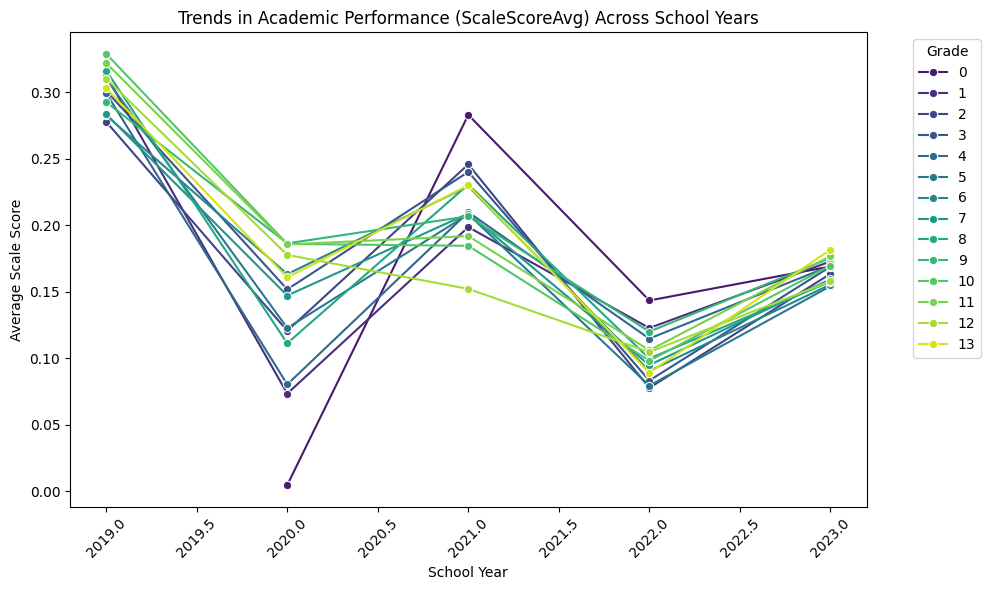

```
This plot shows how ScaleScoreAvg varies across school years, grouped by grade level.
If lines for certain grades slope upward, it suggests improvement in academic performance over time.
Steeper slopes indicate stronger trends, while flat lines suggest stability in performance.
```

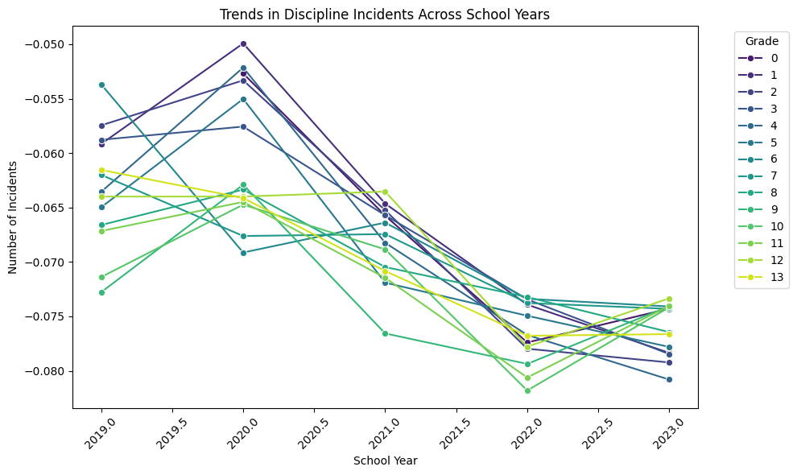

```
This plot shows the frequency of discipline incidents across school years by grade.
Increasing lines indicate rising incidents, while decreasing lines suggest better behavioral outcomes.
```

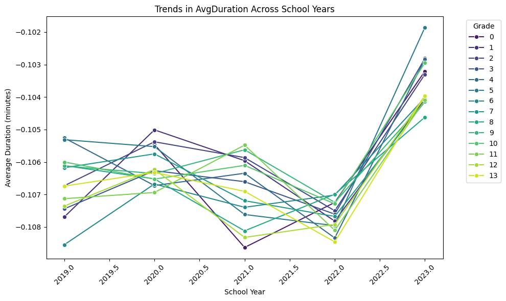

```
This plot examines the average duration of incidents over time.
Decreasing durations may reflect improved behavioral interventions.
```

```python
# Load the datasets
df = pd.read_csv('4_ready_training.csv')

# Ensure data types are correct
df['School Year'] = df['School Year'].astype('category')
df['Grade_Numeric'] = df['Grade_Numeric'].astype('category')

# ==================== TREND ANALYSIS ====================

# Step 1: Analyze Trends for ScaleScoreAvg
plt.figure(figsize=(10, 6))
sns.lineplot(data=scale_score_summary, x="School Year", y="ScaleScoreAvg", hue="Grade_Numeric", marker="o", palette="viridis")
plt.title("Trends in Academic Performance (ScaleScoreAvg) Across School Years")
plt.xlabel("School Year")
plt.ylabel("Average Scale Score")
plt.legend(title="Grade", bbox_to_anchor=(1.05, 1), loc='upper left')
plt.xticks(rotation=45)
plt.tight_layout()
plt.show()

print("\nThis plot shows how ScaleScoreAvg varies across school years, grouped by grade level.")
print("If lines for certain grades slope upward, it suggests improvement in academic performance over time.")
print("Steeper slopes indicate stronger trends, while flat lines suggest stability in performance.\n")


# Step 2: Analyze Trends for Incidents
plt.figure(figsize=(10, 6))
sns.lineplot(data=incident_summary, x="School Year", y="Incidents", hue="Grade_Numeric", marker="o", palette="viridis")
plt.title("Trends in Discipline Incidents Across School Years")
plt.xlabel("School Year")
plt.ylabel("Number of Incidents")
plt.legend(title="Grade", bbox_to_anchor=(1.05, 1), loc='upper left')
plt.xticks(rotation=45)
plt.tight_layout()
plt.show()

print("\nThis plot shows the frequency of discipline incidents across school years by grade.")
print("Increasing lines indicate rising incidents, while decreasing lines suggest better behavioral outcomes.\n")


# Step 3: Analyze Trends for AvgDuration
plt.figure(figsize=(10, 6))
sns.lineplot(data=duration_summary, x="School Year", y="AvgDuration", hue="Grade_Numeric", marker="o", palette="viridis")
plt.title("Trends in AvgDuration Across School Years")
plt.xlabel("School Year")
plt.ylabel("Average Duration (minutes)")
plt.legend(title="Grade", bbox_to_anchor=(1.05, 1), loc='upper left')
plt.xticks(rotation=45)
plt.tight_layout()
plt.show()

print("This plot examines the average duration of incidents over time.")
print("Decreasing durations may reflect improved behavioral interventions.\n")
```